# Assignment-7

Cameron Forsyth

2023-03-02

https://github.com/CamForsyth/Assignment-7

As a young biologist, Dr. Emily Jones had always been fascinated by the world of dragons. She had heard stories of their incredible abilities and magical powers, and had always wanted to uncover the secrets of their evolution.

One day, Dr. Jones stumbled upon an old manuscript that spoke of a legendary trio of dragons - the Purple Dragon, the Fire Dragon, and the Water Dragon. According to the manuscript, these three dragons were the key to unlocking the secrets of dragon heritage.

With her curiosity piqued, Dr. Jones set out to find these dragons and conduct a phylogenetic analysis on their genetic material. She scoured the world for months, visiting remote caves, hidden waterfalls and lava fields in search of the elusive dragons.

Finally, after months of searching, she found them. The Purple Dragon was the first to be discovered, nestled in a hidden cave deep within a mountain range. The Fire Dragon was found next, high atop a volcano, while the Water Dragon was discovered in the depths of the ocean.

Dr. Jones took samples of their scales, talons and saliva and brought them back to her lab for analysis. She spent countless hours poring over the genetic data, using advanced techniques to reconstruct the evolutionary history of the dragons.

```r
library(ape)
library(ggtree)
library(dplyr)
```

```r
Init_Data<-readLines("/Users/Cameron/Documents/Queens/4th Year/Sem2/BIOL432/Week7/Assignment-7/input/DragonMatrix.nex.txt")
```

```r
head(Init_Data)
```

```
## [1] "#NEXUS"
## [2] "begin data;"
## [3] "dimensions ntax=77 nchar=78;"
## [4] "format datatype=binary interleave=no gap=?;"
## [5] "matrix"
## [6] "0.1FishXXX 000000000000000000000000000000000000000000000000000000000000000000000000000000"
```

```r
Drags_New<-c("Purple 111111111100001000111111001001000001000001110110001110000001101110000001100110",
             "Fire   111111111100001000111111001001000001000001110110001110000001101110011000011000",
             "Water  100111111101010010010011001010000010010010100011000001101010101110011100001000")

matrixFind <-grep("0.1FishXXX", Init_Data)

Init_Data <- gsub("ntax=77", "ntax=80", Init_Data)

Init_Data <- c(Init_Data[1:matrixFind-1], Drags_New, Init_Data[matrixFind:length(Init_Data)])


writeLines(Init_Data,"/Users/Cameron/Documents/Queens/4th Year/Sem2/BIOL432/Week7/Assignment-7/input/DragonMatrix.nex.txt")
```

```r
DragonNexus<- read.nexus.data("/Users/Cameron/Documents/Queens/4th Year/Sem2/BIOL432/Week7/Assignment-7/input/DragonMatrix.nex.txt")

DragonNexus
```

```
## $Purple
##  [1] "1" "1" "1" "1" "1" "1" "1" "1" "1" "1" "0" "0" "0" "0" "1" "0" "0" "0" "1"
## [20] "1" "1" "1" "1" "1" "0" "0" "1" "0" "0" "1" "0" "0" "0" "0" "0" "1" "0" "0"
## [39] "0" "0" "0" "1" "1" "1" "0" "1" "1" "0" "0" "0" "1" "1" "1" "0" "0" "0" "0"
## [58] "0" "0" "1" "1" "0" "1" "1" "1" "0" "0" "0" "0" "0" "0" "1" "1" "0" "0" "1"
## [77] "1" "0"
##
## $Fire
##  [1] "1" "1" "1" "1" "1" "1" "1" "1" "1" "1" "0" "0" "0" "0" "1" "0" "0" "0" "1"
## [20] "1" "1" "1" "1" "1" "0" "0" "1" "0" "0" "1" "0" "0" "0" "0" "0" "1" "0" "0"
## [39] "0" "0" "0" "1" "1" "1" "0" "1" "1" "0" "0" "0" "1" "1" "1" "0" "0" "0" "0"
## [58] "0" "0" "1" "1" "0" "1" "1" "1" "0" "0" "1" "1" "0" "0" "0" "0" "1" "1" "0"
## [77] "0" "0"
##
## $Water
```

[output cut: 544 more lines]

```r
WeightsDat<-read.csv("/Users/Cameron/Documents/Queens/4th Year/Sem2/BIOL432/Week7/Assignment-7/Weights.csv")
```

#Creating a single vector of weights

```r
Weights<-paste0(WeightsDat$Weight,collapse="")
Weights<-strsplit(Weights,split="")[[1]]
```

# Converting each letter to a value

```r
WeightsNum<-rep(NA, length(Weights))
for(i in 1:length(WeightsNum)){
  if(Weights[i] %in% LETTERS){
    WeightsNum[i]<-which(LETTERS==Weights[i])+9
  }  else {
    WeightsNum[i]<-Weights[i]
  }
}
WeightsNum<-as.numeric(WeightsNum)

length(WeightsNum)
```

```
## [1] 78
```

# Multiplying the weight value by the trait vector for each dragon

```r
WtDragonNexus<-DragonNexus
for(i in 1:length(DragonNexus)){
  RepWeight<-DragonNexus[[i]]==1
  WtDragonNexus[[i]][RepWeight]<-WeightsNum[RepWeight]
  RepWeight<-NA
}
```

#Recalculating our distance matrix

```r
WtDragonNexusDF<-data.frame(matrix(unlist(WtDragonNexus), ncol=78, byrow=T))
row.names(WtDragonNexusDF)<-names(WtDragonNexus)
WtDragonDist<-dist(WtDragonNexusDF, method='euclidean')
WtDragonDistMat<-as.matrix(WtDragonDist)
```

# Plotting the tree

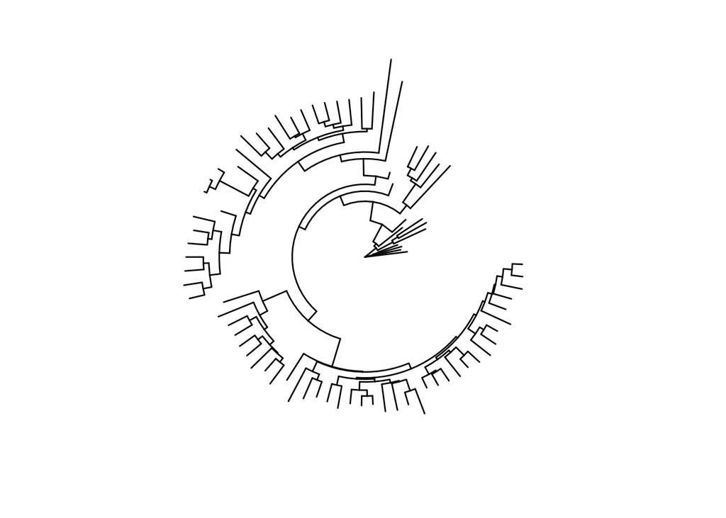

```r
WtDragonTree<-fastme.bal(WtDragonDist)
WtDragonTreeNJ<-nj(WtDragonDist)
ggtree(WtDragonTree,layout="circular")
```

```r
str(WtDragonTree)
```

```
## List of 4
##  $ edge       : int [1:157, 1:2] 81 81 82 83 84 85 86 87 88 89 ...
##  $ edge.length: num [1:157] 13.626 4.603 0.992 6.228 6.069 ...
##  $ tip.label  : chr [1:80] "Purple" "39ItalianX" "47ItalianX" "54IranianX" ...
##  $ Nnode      : int 78
##  - attr(*, "class")= chr "phylo"
##  - attr(*, "order")= chr "cladewise"
```

```r
head(WtDragonTree$tip.label)
```

```
## [1] "Purple"     "39ItalianX" "47ItalianX" "54IranianX" "41EnglishX"
## [6] "71BritishX"
```

```r
Location<-gsub("[0-9\\.]+([^X]+)X*","\\1",WtDragonTree$tip.label)

LocationGroups<-split(WtDragonTree$tip.label, Location)

WtDTcol<-groupOTU(WtDragonTree,LocationGroups)
str(WtDTcol)
```

```
## List of 4
##  $ edge       : int [1:157, 1:2] 81 81 82 83 84 85 86 87 88 89 ...
##  $ edge.length: num [1:157] 13.626 4.603 0.992 6.228 6.069 ...
##  $ tip.label  : chr [1:80] "Purple" "39ItalianX" "47ItalianX" "54IranianX" ...
##  $ Nnode      : int 78
##  - attr(*, "class")= chr "phylo"
##  - attr(*, "order")= chr "cladewise"
##  - attr(*, "group")= Factor w/ 22 levels "3","American",..: 16 13 13 12 5 3 19 13 3 13 ...
```

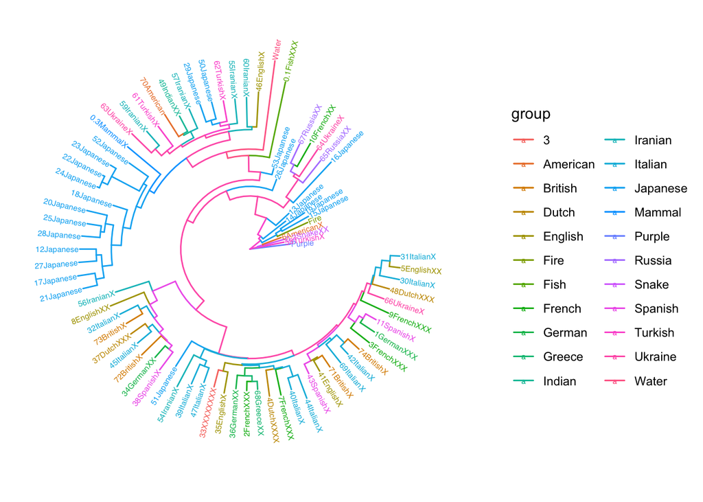

```r
ggtree(WtDTcol,layout="circular", aes(colour=group)) +
  geom_tiplab(size=2,aes(angle=angle))
```

She found that the Purple dragon was one of the oldest dragons that shares the common ancestor with all other dragons. No other dragons appeared to come from its lineage. The Fire dragon appears to be most closely related to the Japanese lineage. Lastly, the Water dragon underwent several speciation events and is less closely related to the other 2. It’s previous divergence resulted in the fish species and the Turkish/Ukrainian lineage.

Dr. Jones’ research on the three dragons became a landmark study in the field of dragon genetics, providing new insights into the evolution of these mythical creatures. Her work paved the way for further research on dragon heritage, and helped unravel some of the mysteries surrounding these fascinating creatures.

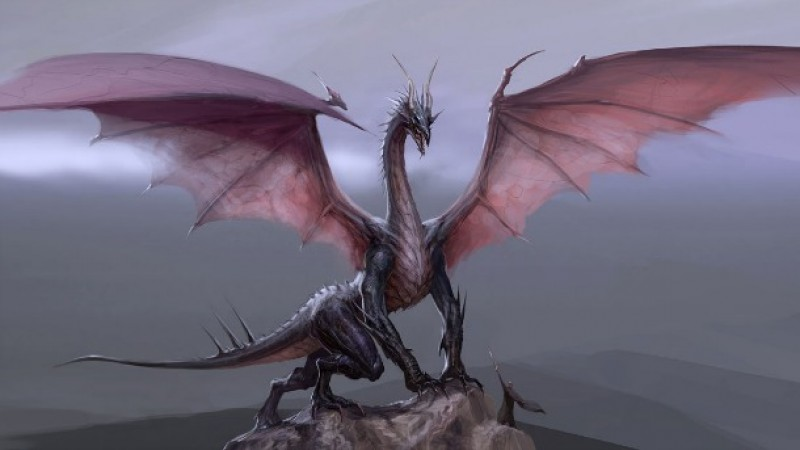

```r
knitr::include_graphics("/Users/Cameron/Documents/Queens/4th Year/Sem2/BIOL432/Week7/Assignment-7/images/Dragon1.jpeg")
```

Hyperlink: https://www.gameinformer.com/b/features/archive/2013/08/30/putting-the-dragons-in-dragon-age.aspx

Figure 1 Citation: Juba, Joe. “Putting The Dragons In Dragon Age.” Gameinformer, 30 Aug. 2013, https://www.gameinformer.com/b/features/archive/2013/08/30/putting-the-dragons-in-dragon-age.aspx. Accessed 28 Feb. 2023.

[figure not shown]

```r
knitr::include_graphics("/Users/Cameron/Documents/Queens/4th Year/Sem2/BIOL432/Week7/Assignment-7/images/Dragon2.jpeg")
```

https://articles.starcitygames.com/magic-the-gathering/baldurs-gate-commander-flavor-review-here-be-dragons/

Figure 2 Citation: Hess, Karington. “Baldur’s Gate Commander Flavor Review: Here Be Dragons.” Star City Games, 3 June 2022, https://articles.starcitygames.com/magic-the-gathering/baldurs-gate-commander-flavor-review-here-be-dragons/.

[figure not shown]

```r
knitr::include_graphics("/Users/Cameron/Documents/Queens/4th Year/Sem2/BIOL432/Week7/Assignment-7/images/Dragon3.jpeg")
```

https://kiarayew.com/romanian-dragons/

Figure 3 Citation: Iorga, Maria. “Romanian Dragons | Magical Creatures.” The Adventures of Kiara Yew, 20 Apr. 2020, https://kiarayew.com/romanian-dragons/.